# Part2-Question2

GROUP 14

03 12 2019

QUESTION 2

For starters, we read the image into “img”. The matrix img then will be divided into windows of 51x51. Through the process we jump by 5 for the dimensions in the for loop to create the subgrouped matrix of 51x51 windows. Jumping by 1 unit at a time consumes a considerable time for Rstudio as the for loops are slow and impossible in some cases in the process. by 1 to 51, and then 6 to 56, the for loop constructs the windows. Since the inital row is all zeros, it’s excluded from the matrix as it can affect the regression model. Moving on, the 1301st cell is excluded from the regression model as it’s the value that’s to be estimated by the model with the code “model <- lm(V1301~. , data = regression_mat).” The obtained matrix is then turned into a dataframe as we’ll use it as one. Then, with the anova, sum, residuals, and qqnorm functions the information of the regression model is obtained. qqnorm function checks if the residuals of the model follow normal distribution. The results points out that the residuals are on a straight line on the q-q chart which indicates that they indeed follow normal distribution. Embarking on with the residuals, with the qic package, control charts for residuals are obtained. After this procedure, the for loop checks the rows of the matrix to eliminate the outlier residuals within the charts. With the LCL and UCL feature of the qic package, 24 residuals are assigned to the value of 0. Finally, the diffence between the original image and the edited can be seen on the plots. As it appears on the plots, There’s a slight change in the image. Since the number of outliers detected are only 24, the effect of it on the image is barely visible. Again, the black dots are visible on specific areas, however, not intensely. This indicates that the regression assumption works and the outlier residuals are eliminated.

To eliminate the autocorrelation problem, the best way to proceed is to extend the distances between the windows. Jumping by 1 at a time increases the autocorrelation since the cells are closer to each other and in turn they affect each other considerable more. Instead of jumping by 5, as we did in the task, a better way could be jumping by 10 units at a time. This could decrease the effect of autocorrelation since the cells would have a longer distance among each other. Another way to decrease the effect of autocorrelation is to use the least squares method, however the method requires a series of function that we’ll not be dealing with in this task.

```r
library(jpeg)
img <- readJPEG("group_14_gri.jpg")

regression_mat <- 0
matr_vec <- rep(0,1000)

h <- 0
t <-0

for( h in 1:69){
  for( t in 1:69){

    matr <- img[(5*(h-1)+1):((5*(h-1))+51),(5*(t-1)+1):((5*(t-1))+51)]
    matr_vec <- as.vector(matr)

  regression_mat <- rbind(regression_mat, matr_vec)

  }
}

dim(regression_mat)
```

```
## [1] 4762 2601
```

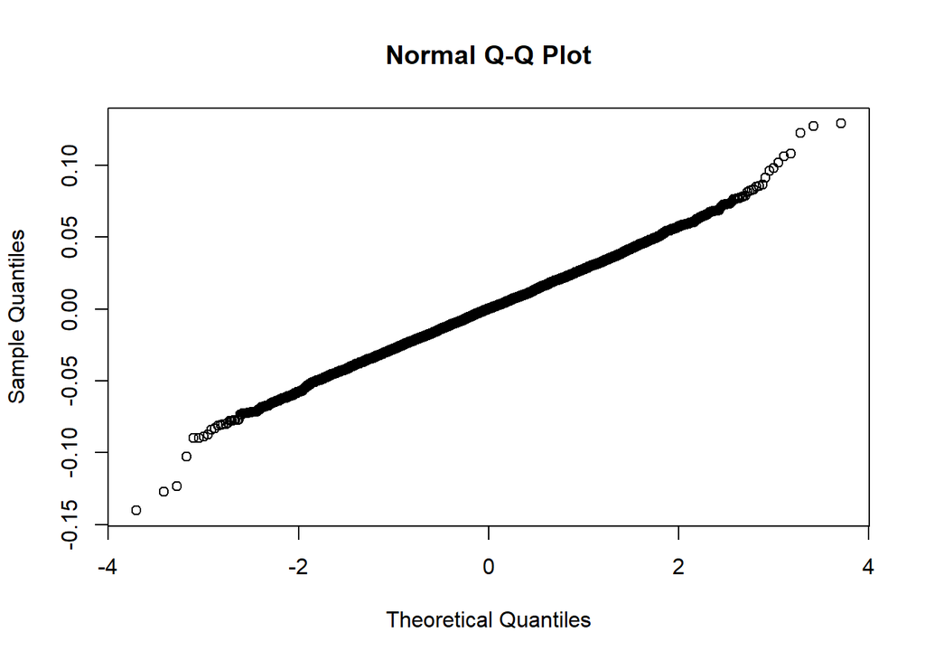

```r
regression_mat<- regression_mat[-1,]
regression_mat <- as.data.frame(regression_mat)

model <- lm(V1301~.  , data = regression_mat)


anova <- anova(model)

sum <- summary(model)

residual_vec <- residuals(model)

qqnorm(residuals(model))


library(qicharts)
```

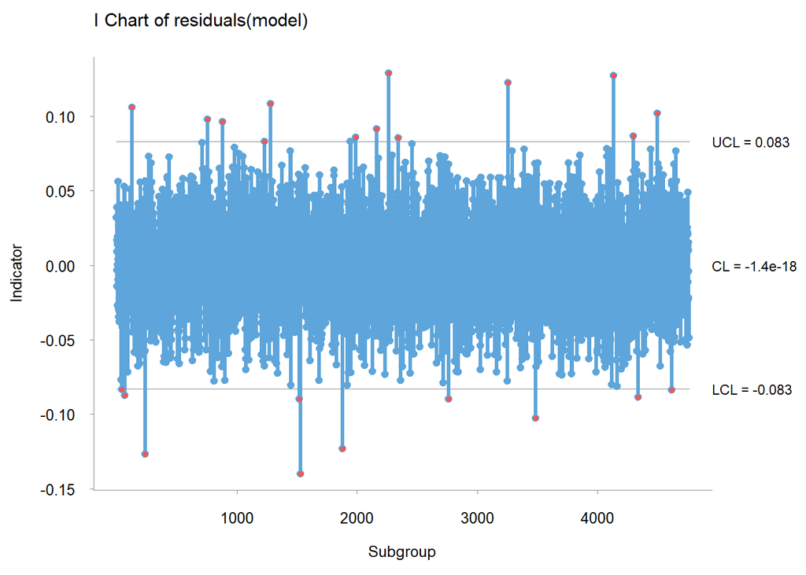

```r
image_reg <- img

out_cpntrol_vect <- 0
a <- 1

controlc_residuals <- qic(residuals(model), chart = 'i')
```

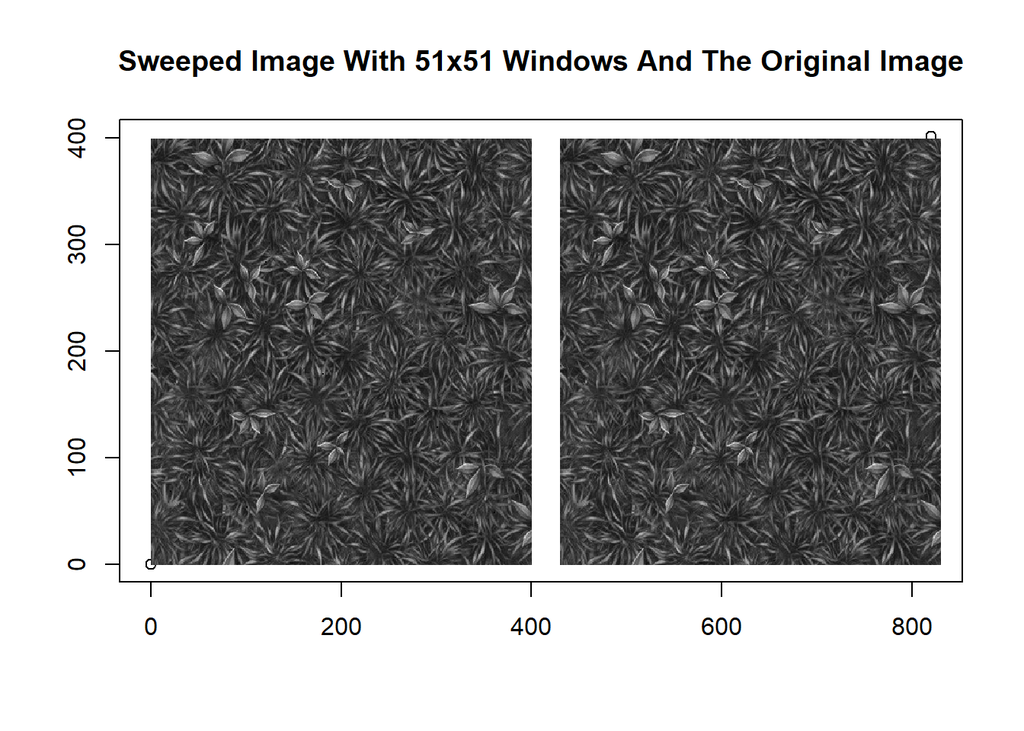

```r
for(j in 1:4761){
  if( residual_vec[j] < controlc_residuals$lcl[1] || residual_vec[j] > controlc_residuals$ucl[1] ){
    image_reg[(((ceiling(j/70))-1)*5+26),(((ceiling(j%%70))-1)*5+26)] <- 0
    out_cpntrol_vect[a] <- j
    a <- a + 1
  }

}

op1 <- par()
plot(c(0, 820), c(0, 401), xlab = "", ylab = "")
title(paste("Sweeped Image With 51x51 Windows And The Original Image"))
rasterImage(image_reg, 0, 0, 400, 400, interpolate = FALSE)
rasterImage(img, 430, 0, 830, 400,interpolate = FALSE )
```

```r
par(op1)
```